# 1 Sou bom no arco e flecha?

## 1.1 Objetivo

Introduzir os visitantes da mostra a ideia de estimadores e suas propriedades atraves de uma brincadeira de arco e flecha.

## 1.2 Motivacao

## 1.3 Construcao

## 1.4 Execucao

## 1.5 Teoria

### 1.5.1 Estimadores

Suponha que o centro do alvo, *bullseye*, seja a estatistica $\theta$ que desejamos estimar de uma populacao $S$.

E tambem suponha que cada flecha lancada seja uma tentativa de estimar $\theta$, com um estimator $\hat{\theta}(s_i)$, onde $s$ é uma amostra de tamanho $S$.

Nesse caso as propriedades do estimador $\hat{\theta}$ serao influenciadas pela abilidade do participante com o arco e flecha. Propriedades essas como variância e viés.

#### 1.5.1.1 Algumas propriedades de estimadores

Sendo
$$\begin{equation}
E[\hat{\theta}] = \sum_{s \in S} {\hat{\theta}(s)} p(s) \tag{1.1}
\end{equation}$$

a variância de um estimador e dada por

$$\begin{equation}
Var[\hat{\theta}] = E[(\hat{\theta}-E[\hat{\theta}])^2] \tag{1.2}
\end{equation}$$

e o viés de um estimador e dado por

$$\begin{equation}
B[\hat{\theta}] = E[\hat{\theta}] - \theta \tag{1.3}
\end{equation}$$

Trazendo esses conceitos para o experimento podemos definir o viés como sendo “distancia entre a posicao media das flechas com relacao ao alvo” e a variância como sendo “soma das distancias quadradas medias entre as posicoes das flechas”.

#### 1.5.1.2 Exemplo pratico

Suponha tres participantes, nossos “estimadores”, representados pelas cores laranja, verde e azul, onde cada um teve a chance de disparar tres flechas com o intuito de acertar o alvo, ou tres amostras $s$ para tentar estimar $\theta$.

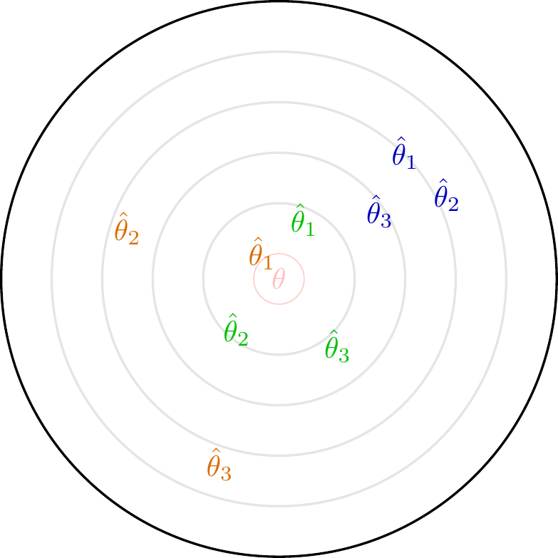

Figure 1.1: Posição final das flechas disparadas.

Ao observar a figura 1.1 podemos perceber que o participante azul e o que apresenta o estimador com menor variância porem com o maior viés, ja o laranja foi o que chegou mais proximo do centro porem apresenta grande variância e algum viés por ultimo o participante verde foi o que apresentou menor viés com uma variância pequena.

Logo nesse caso especifico podemos concluir que o participante verde possui o melhor estimador de $\theta$.

## 1.6 Referencias

https://amostragemcomr.github.io/livro/visger.html#estat%C3%ADsticas-estimadores-e-estimativas